# Cluster Validation using the clValid R Package

```r
#Check the Silhouette Values
LmOB2_pam$silinfo
```

```
## $widths
##            cluster neighbor sil_width
## 08-4802          1        2 0.6031405
## 08-5371          1        2 0.6030436
## 08-7275          1        2 0.6008894
## 08-7006          1        2 0.6004124
## 08-5581          1        2 0.5938471
## 08-7007          1        2 0.5881203
## 08-4805          1        2 0.5852064
## 08-5373          1        2 0.5837669
## 08-5828          1        2 0.5822797
## 08-6308          1        2 0.5766811
## 08-6136          1        2 0.5765207
## 08-6309          1        2 0.5685360
## 08-6406          1        2 0.5628332
## 08-6137          1        2 0.5246589
## 08-5372          1        2 0.5053102
## 08-5703          1        2 0.5001716
## 08-6997          1        2 0.4990524
## 08-5376          1        2 0.4889182
## 08-5758          1        2 0.4620518
## 08-6132          1        2 0.4522967
## 08-6306          1        2 0.4515614
## 08-6031          1        2 0.4293419
## 08-6311          1        2 0.4253421
## 08-6537          1        2 0.4009417
## 08-5580          1        2 0.4007564
## 08-6211          1        2 0.3729870
## 08-5489          1        2 0.3568552
## 08-6337          1        2 0.3327128
## 08-6071          1        2 0.3210994
## 08-5583          1        2 0.2933373
## 08-6336          1        2 0.2785299
## 08-5243          2        4 0.4412379
## 08-5319          2        4 0.4412379
## 08-6706          2        4 0.4412379
## 08-6421          2        4 0.4315701
## 08-5924          2        4 0.4203206
## 08-5761          2        4 0.4118230
## 08-7140          2        4 0.4106938
```

[output cut: 27 more lines]

```
## OLF16009-5       5        6 0.7519941
## OLF16008-2       5        6 0.7311142
## 16-0532          5        6 0.7181148
## OLF16007-1       5        6 0.7067977
## 15-8753          5        6 0.6985368
## OLF16006-1       5        6 0.6661648
## OLF16008-1       5        6 0.6370689
## 15C1046165       5        6 0.1635457
## 15S0018124       6        5 0.0000000
##
## $clus.avg.widths
## [1] 0.4877807 0.3228561 0.0000000 0.5835358 0.6686421 0.0000000
##
## $avg.width
## [1] 0.4487117
```

```
##   cluster size ave.sil.width
## 1       1   31          0.49
## 2       2   26          0.32
## 3       3    1          0.00
## 4       4    4          0.58
## 5       5   11          0.67
## 6       6    1          0.00
```

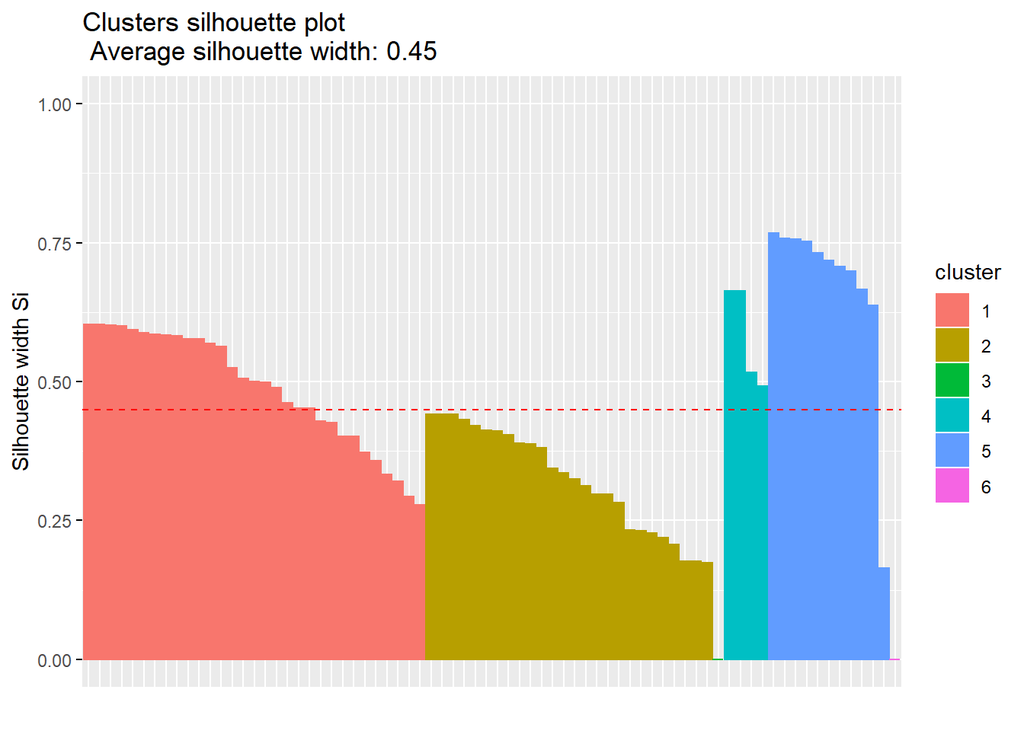

```r
#Plot Sil Width
fviz_silhouette(LmOB2_pam)
```

Using the eclust and cluster.stats functions, a PAM clustering with k=6 clusters was considered to be optimal. Although more clusters were identified, the observations associated with RTE meat (clusters 1-4) are clustered separately from observations associated with an exposure to leafy greens (clusters 5-6). The average Silhouette Width (0.4487) is also consistent with the average Silhouette Width reported by clValid for the PAM algorithm with 6 clusters (0.4487).

```r
set.seed(1234)

#Assess the Hierarchical Clustering Algorithm
LmOB2_hc = eclust(LmOB2, FUNcluster = "hclust", k = NULL, k.max = 7, hc_metric = "euclidean", hc_method = "average", graph = FALSE)

#View the cluster validation statistics using the cluster.stats function in the fpc R package
hc_LmOB2stats  = cluster.stats(dist(LmOB2),  LmOB2_hc$cluster)



#Results Summary
#Number of Clusters = 7
#Cluster Size = 29, 30, 1, 1, 1, 11, 1
#Silhouette Width = 0.4570
#Dunn Index = 0.7618

#View the cluster number for each observation
LmOB2_hc$cluster
```

```
##    08-4802    08-4805    08-5243    08-5319    08-5371    08-5372
##          1          1          2          2          1          1
##    08-5373    08-5376    08-5377    08-5378    08-5489    08-5577
##          1          1          2          2          1          3
##    08-5578    08-5580    08-5581    08-5583    08-5703    08-5756
##          2          1          1          4          1          2
##    08-5758    08-5759    08-5761    08-5826    08-5827    08-5828
##          1          2          2          2          2          1
##    08-5871    08-5924    08-6030    08-6031    08-6032    08-6033
##          2          2          2          1          2          2
##    08-6056    08-6069    08-6071    08-6132    08-6133    08-6134
##          2          2          1          1          2          2
##    08-6135    08-6136    08-6137    08-6211    08-6306    08-6308
##          2          1          1          1          1          1
##    08-6309    08-6311    08-6335    08-6336    08-6337    08-6406
##          1          1          2          5          1          1
##    08-6421    08-6537    08-6569    08-6706    08-6997    08-7006
##          2          1          2          2          1          1
##    08-7007    08-7140    08-7275    08-7373    08-7374    08-7547
##          1          2          1          2          2          2
##    10-0814    10-0815    15-8753    15-9019 15C1046165 15S0018124
##          2          2          6          6          6          7
##    16-0117    16-0532 OLF16006-1 OLF16007-1 OLF16008-1 OLF16008-2
##          6          6          6          6          6          6
## OLF16009-3 OLF16009-5
##          6          6
```

```r
#Check the Silhouette Values
LmOB2_hc$silinfo
```

```
## $widths
##            cluster neighbor sil_width
## 08-4802          1        4 0.5957631
## 08-5371          1        4 0.5957069
## 08-7275          1        4 0.5931028
## 08-7006          1        4 0.5899381
## 08-7007          1        4 0.5755756
## 08-4805          1        4 0.5752715
## 08-5373          1        4 0.5732475
## 08-5581          1        4 0.5724115
## 08-5828          1        4 0.5598362
## 08-6136          1        4 0.5557878
## 08-6309          1        4 0.5467233
## 08-6308          1        4 0.5406100
## 08-6406          1        4 0.5311015
## 08-5372          1        4 0.4874964
## 08-6997          1        4 0.4744234
## 08-5376          1        4 0.4679888
## 08-6137          1        4 0.4525715
## 08-5703          1        4 0.4141779
## 08-6031          1        4 0.4011214
## 08-6132          1        5 0.3811434
## 08-5758          1        4 0.3607523
## 08-6306          1        4 0.3567084
## 08-6311          1        5 0.3036957
## 08-5580          1        4 0.3013940
## 08-6537          1        4 0.2721439
## 08-6071          1        4 0.2715514
## 08-6211          1        4 0.2424322
## 08-5489          1        5 0.1798745
## 08-6337          1        5 0.1463961
## 08-5243          2        1 0.5732700
## 08-5319          2        1 0.5732700
## 08-6706          2        1 0.5732700
## 08-6421          2        1 0.5663410
## 08-5924          2        1 0.5573216
## 08-7140          2        1 0.5537141
## 08-5761          2        1 0.5500567
## 08-6135          2        1 0.5385937
## 08-6134          2        1 0.5282648
```

[output cut: 27 more lines]

```
## OLF16009-5       6        7 0.7519941
## OLF16008-2       6        7 0.7311142
## 16-0532          6        7 0.7181148
## OLF16007-1       6        7 0.7067977
## 15-8753          6        7 0.6985368
## OLF16006-1       6        7 0.6661648
## OLF16008-1       6        7 0.6370689
## 15C1046165       6        7 0.1635457
## 15S0018124       7        6 0.0000000
##
## $clus.avg.widths
## [1] 0.4454809 0.4513868 0.0000000 0.0000000 0.0000000 0.6686421 0.0000000
##
## $avg.width
## [1] 0.4569678
```

```
##   cluster size ave.sil.width
## 1       1   29          0.45
## 2       2   30          0.45
## 3       3    1          0.00
## 4       4    1          0.00
## 5       5    1          0.00
## 6       6   11          0.67
## 7       7    1          0.00
```

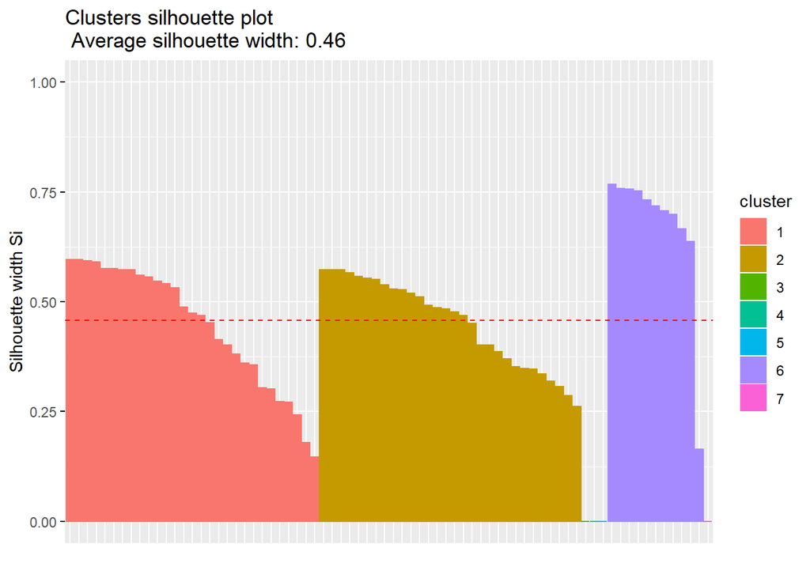

```r
#Plot the Silhouette Values
fviz_silhouette(LmOB2_hc)
```

Using the eclust function, a hierarchical clustering with k=7 clusters was considered to be optimal, which was not in agreement with the clValid results (k=2) for the same dataset. Although the observations were split into many more clusters (i.e., 7) with the eclust function in comparison to clValid, the observations associated with the RTE Meat Outbreak are clustered separately (clusters 1-5) from the observations associated with the Leafy Green Outbreak (clusters 6-7). Additionally, the average Silhouette Width (0.4570) is consistent with the average Silhouette Width reported by *clValid* for the hierarchical algorithm with 7 clusters (0.4570).

To determine whether the eclust and cluster.stats functions return comparable values to those reported by *clValid* for the optimal clustering algorithm and number of clusters (i.e., hierarchical, k=2), the Outbreak 1 dataset was re-evaluated with the number of clusters (k) adjusted to k=2.

```r
set.seed(1234)

###Re-evaluate Outbreak 1 using the optimal number of cluster identified by clValid for the hierarchical clustering algorithm

#Assess the Hierarchical Clustering Algorithm with k=2
LmOB2_hc2 = eclust(LmOB2, FUNcluster = "hclust", k = 2, k.max = 7, hc_metric = "euclidean", hc_method = "average", graph = FALSE)

#View the cluster validation statistics using the cluster.stats function in the fpc R package
hc_LmOB2stats2 = cluster.stats(dist(LmOB2), LmOB2_hc2$cluster)


#Results Summary
#Number of Clusters = 2
#Cluster Size = 62, 12
#Silhouette Width = 0.6934
#Dunn Index = 1.1787


#View the cluster number for each observation
LmOB2_hc2$cluster
```

```
##    08-4802    08-4805    08-5243    08-5319    08-5371    08-5372
##          1          1          1          1          1          1
##    08-5373    08-5376    08-5377    08-5378    08-5489    08-5577
##          1          1          1          1          1          1
##    08-5578    08-5580    08-5581    08-5583    08-5703    08-5756
##          1          1          1          1          1          1
##    08-5758    08-5759    08-5761    08-5826    08-5827    08-5828
##          1          1          1          1          1          1
##    08-5871    08-5924    08-6030    08-6031    08-6032    08-6033
##          1          1          1          1          1          1
##    08-6056    08-6069    08-6071    08-6132    08-6133    08-6134
##          1          1          1          1          1          1
##    08-6135    08-6136    08-6137    08-6211    08-6306    08-6308
##          1          1          1          1          1          1
##    08-6309    08-6311    08-6335    08-6336    08-6337    08-6406
##          1          1          1          1          1          1
##    08-6421    08-6537    08-6569    08-6706    08-6997    08-7006
##          1          1          1          1          1          1
##    08-7007    08-7140    08-7275    08-7373    08-7374    08-7547
##          1          1          1          1          1          1
##    10-0814    10-0815    15-8753    15-9019 15C1046165 15S0018124
##          1          1          2          2          2          2
##    16-0117    16-0532 OLF16006-1 OLF16007-1 OLF16008-1 OLF16008-2
##          2          2          2          2          2          2
## OLF16009-3 OLF16009-5
##          2          2
```

```
##   cluster size ave.sil.width
## 1       1   62          0.67
## 2       2   12          0.83
```

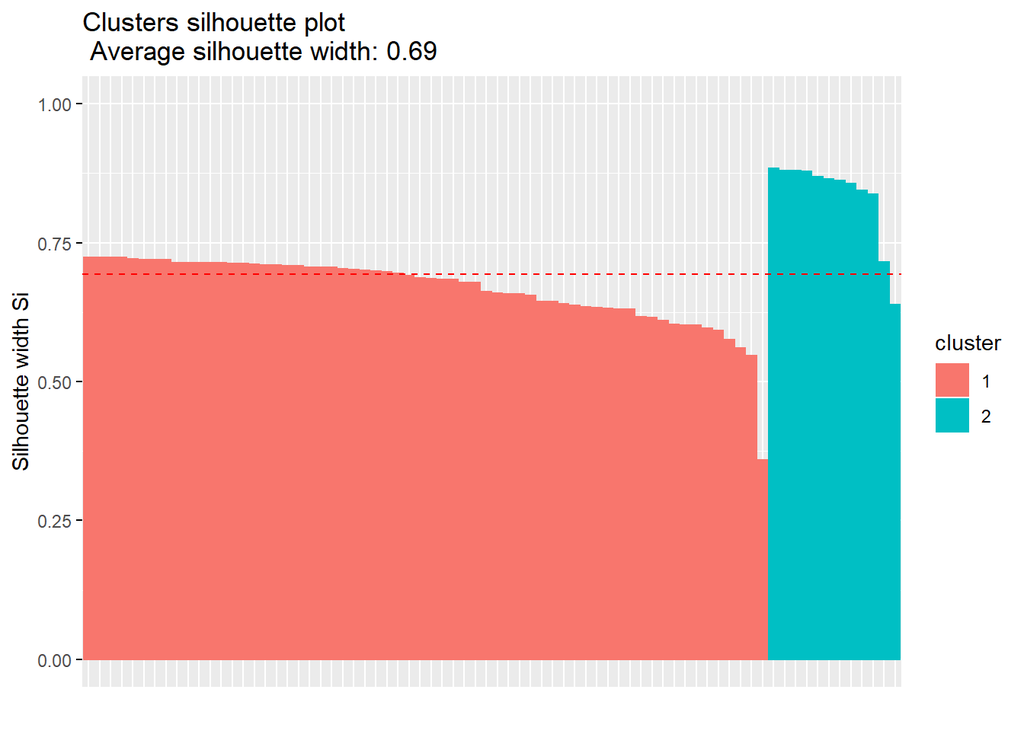

```r
#Plot Sil Width
fviz_silhouette(LmOB2_hc2)
```

Following an adjustment of the number of clusters to k=2 for the hierarchical clustering algorithm, the summary statistics returned by the eclust function and the cluster.stats function were nearly identical to those obtained by the *clValid* package. Thus, the results suggest that k=2 leads to a more appropriate clustering of the observations according to the outbreak they are associated with.